# Case Study 2

Jaclyn A Coate

2019-11-22

# Exploratory Data Analysis

- Linear Regression
- Multiple Linear Regression
- Correlation
- Causation?

## Steps For EDA w/ Large Number of Categories / Continuous Variables

1. Check for NAs
2. Get rid of zero value variables (ones that only have one value).
3. Use common sense! (variables that don’t makes sense remove from your list of variables)
   - e.g. ID, Employee Number
4. Check and make sure categorical variables are stored as factors.
   - e.g. Make sure all variables are categorized correctly - categorical (stock options) or numeric
5. Storing all level numeric variables as factors
   - e.g. Job Level, College, etc.
6. Checking for highly correlated numeric variables
   - Highly correlated values can weaken the model.
   - e.g. Monthly Salary, Weekly Salary, they say the same thing and would be highly correlated
7. Numeric | Categorical
8. Categorical | Categorical
9. KNN Model Variables to Reduce

```r
frito <- read.csv("https://raw.githubusercontent.com/JaclynCoate/MDS-6306-Doing-Data-Science-Fall-2019/Master/Unit%2014%20and%2015%20Case%20Study%202/CaseStudy2-data.csv", header = TRUE, strip.white=TRUE)
frito
invisible(ncol(frito))
invisible(skim(frito))
```

### 1. Missing data evaluation

- No missing values
- Continue w/ exploratory data analysis

```r
md.pattern(frito)
```

```
##  /\     /\
## {  `---'  }
## {  O   O  }
## ==>  V <==  No need for mice. This data set is completely observed.
##  \  \|/  /
##   `-----'
```

[figure not shown]

```
##     ID Age Attrition BusinessTravel DailyRate Department DistanceFromHome
## 870  1   1         1              1         1          1                1
##      0   0         0              0         0          0                0
##     Education EducationField EmployeeCount EmployeeNumber
## 870         1              1             1              1
##             0              0             0              0
##     EnvironmentSatisfaction Gender HourlyRate JobInvolvement JobLevel
## 870                       1      1          1              1        1
##                           0      0          0              0        0
##     JobRole JobSatisfaction MaritalStatus MonthlyIncome MonthlyRate
## 870       1               1             1             1           1
##           0               0             0             0           0
##     NumCompaniesWorked Over18 OverTime PercentSalaryHike PerformanceRating
## 870                  1      1        1                 1                 1
##                      0      0        0                 0                 0
##     RelationshipSatisfaction StandardHours StockOptionLevel
## 870                        1             1                1
##                            0             0                0
##     TotalWorkingYears TrainingTimesLastYear WorkLifeBalance YearsAtCompany
## 870                 1                     1               1              1
##                     0                     0               0              0
##     YearsInCurrentRole YearsSinceLastPromotion YearsWithCurrManager
## 870                  1                       1                    1 0
##                      0                       0                    0 0
```

### 2. Dropping all zero variance variables

- Drop Variables: EmployeeCount, Over18, StandardHours due to zero variance in sd column of skim() feature output

```r
invisible(skim(frito))
#unique(frito$EmployeeCount)
frito2 <- select(frito, -c("EmployeeCount", "Over18", "StandardHours"))
skim(frito2)
```

```
## Skim summary statistics
##  n obs: 870
##  n variables: 33
##
## ── Variable type:factor ──────────────────────────────────────────────────────────────────────────────────────────────────
##        variable missing complete   n n_unique
##       Attrition       0      870 870        2
##  BusinessTravel       0      870 870        3
##      Department       0      870 870        3
##  EducationField       0      870 870        6
##          Gender       0      870 870        2
##         JobRole       0      870 870        9
##   MaritalStatus       0      870 870        3
##        OverTime       0      870 870        2
##                             top_counts ordered
##               No: 730, Yes: 140, NA: 0   FALSE
##     Tra: 618, Tra: 158, Non: 94, NA: 0   FALSE
##     Res: 562, Sal: 273, Hum: 35, NA: 0   FALSE
##  Lif: 358, Med: 270, Mar: 100, Tec: 75   FALSE
##              Mal: 516, Fem: 354, NA: 0   FALSE
##  Sal: 200, Res: 172, Lab: 153, Man: 87   FALSE
##    Mar: 410, Sin: 269, Div: 191, NA: 0   FALSE
##               No: 618, Yes: 252, NA: 0   FALSE
##
## ── Variable type:integer ─────────────────────────────────────────────────────────────────────────────────────────────────
##                  variable missing complete   n     mean      sd   p0
##                       Age       0      870 870    36.83    8.93   18
##                 DailyRate       0      870 870   815.23  401.12  103
##          DistanceFromHome       0      870 870     9.34    8.14    1
##                 Education       0      870 870     2.9     1.02    1
##            EmployeeNumber       0      870 870  1029.83  604.79    1
##   EnvironmentSatisfaction       0      870 870     2.7     1.1     1
##                HourlyRate       0      870 870    65.61   20.13   30
##                        ID       0      870 870   435.5   251.29    1
##            JobInvolvement       0      870 870     2.72    0.7     1
##                  JobLevel       0      870 870     2.04    1.09    1
##           JobSatisfaction       0      870 870     2.71    1.11    1
##             MonthlyIncome       0      870 870  6390.26 4597.7  1081
##               MonthlyRate       0      870 870 14325.62 7108.38 2094
##        NumCompaniesWorked       0      870 870     2.73    2.52    0
```

[output cut: 22 more lines]

```
##     2        3       4        4 ▅▁▅▁▁▇▁▇
##  2839.5   4945.5  8182    19999 ▇▇▃▂▁▁▁▁
##  8092    14074.5 20456.25 26997 ▆▇▇▇▇▆▇▆
##     1        2       4        9 ▇▂▂▂▁▁▁▁
##    12       14      18       25 ▇▇▃▃▁▂▂▁
##     3        3       3        4 ▇▁▁▁▁▁▁▂
##     2        3       4        4 ▅▁▅▁▁▇▁▇
##     0        1       1        3 ▇▁▇▁▁▂▁▁
##     6       10      15       40 ▅▇▂▂▁▁▁▁
##     2        3       3        6 ▁▁▇▇▁▂▂▁
##     2        3       3        4 ▁▁▃▁▁▇▁▂
##     3        5      10       40 ▇▅▁▁▁▁▁▁
##     2        3       7       18 ▇▂▁▅▁▁▁▁
##     0        1       3       15 ▇▂▁▁▁▁▁▁
##     2        3       7       17 ▇▂▁▃▁▁▁▁
```

```r
ncol(frito2)
```

```
## [1] 33
```

### 3. Remove logically irrelevant variables

- “EmployeeNumber”: not related to attrition
- “ID”: not related to attrition
- “PerformanceRating” : removed because this is a self given performacne rating and emoloyees would still work towards the best raises even when possibly planning on leaving the company

```r
#skim(frito2)
#view(frito2)

frito3 <- select(frito2, -c("EmployeeNumber", "ID", "PerformanceRating"))
skim(frito3)
```

```
## Skim summary statistics
##  n obs: 870
##  n variables: 30
##
## ── Variable type:factor ──────────────────────────────────────────────────────────────────────────────────────────────────
##        variable missing complete   n n_unique
##       Attrition       0      870 870        2
##  BusinessTravel       0      870 870        3
##      Department       0      870 870        3
##  EducationField       0      870 870        6
##          Gender       0      870 870        2
##         JobRole       0      870 870        9
##   MaritalStatus       0      870 870        3
##        OverTime       0      870 870        2
##                             top_counts ordered
##               No: 730, Yes: 140, NA: 0   FALSE
##     Tra: 618, Tra: 158, Non: 94, NA: 0   FALSE
##     Res: 562, Sal: 273, Hum: 35, NA: 0   FALSE
##  Lif: 358, Med: 270, Mar: 100, Tec: 75   FALSE
##              Mal: 516, Fem: 354, NA: 0   FALSE
##  Sal: 200, Res: 172, Lab: 153, Man: 87   FALSE
##    Mar: 410, Sin: 269, Div: 191, NA: 0   FALSE
##               No: 618, Yes: 252, NA: 0   FALSE
##
## ── Variable type:integer ─────────────────────────────────────────────────────────────────────────────────────────────────
##                  variable missing complete   n     mean      sd   p0
##                       Age       0      870 870    36.83    8.93   18
##                 DailyRate       0      870 870   815.23  401.12  103
##          DistanceFromHome       0      870 870     9.34    8.14    1
##                 Education       0      870 870     2.9     1.02    1
##   EnvironmentSatisfaction       0      870 870     2.7     1.1     1
##                HourlyRate       0      870 870    65.61   20.13   30
##            JobInvolvement       0      870 870     2.72    0.7     1
##                  JobLevel       0      870 870     2.04    1.09    1
##           JobSatisfaction       0      870 870     2.71    1.11    1
##             MonthlyIncome       0      870 870  6390.26 4597.7  1081
##               MonthlyRate       0      870 870 14325.62 7108.38 2094
##        NumCompaniesWorked       0      870 870     2.73    2.52    0
##         PercentSalaryHike       0      870 870    15.2     3.68   11
##  RelationshipSatisfaction       0      870 870     2.71    1.1     1
```

[output cut: 16 more lines]

```
##     1       2       3        5 ▇▇▁▃▁▂▁▁
##     2       3       4        4 ▅▁▅▁▁▇▁▇
##  2839.5  4945.5  8182    19999 ▇▇▃▂▁▁▁▁
##  8092   14074.5 20456.25 26997 ▆▇▇▇▇▆▇▆
##     1       2       4        9 ▇▂▂▂▁▁▁▁
##    12      14      18       25 ▇▇▃▃▁▂▂▁
##     2       3       4        4 ▅▁▅▁▁▇▁▇
##     0       1       1        3 ▇▁▇▁▁▂▁▁
##     6      10      15       40 ▅▇▂▂▁▁▁▁
##     2       3       3        6 ▁▁▇▇▁▂▂▁
##     2       3       3        4 ▁▁▃▁▁▇▁▂
##     3       5      10       40 ▇▅▁▁▁▁▁▁
##     2       3       7       18 ▇▂▁▅▁▁▁▁
##     0       1       3       15 ▇▂▁▁▁▁▁▁
##     2       3       7       17 ▇▂▁▃▁▁▁▁
```

```r
ncol(frito3)
```

```
## [1] 30
```

```r
view(frito3)
```

### 4. Storing all categorical variables as factors

```r
# Categorical Variables
skim(frito3)
```

```
## Skim summary statistics
##  n obs: 870
##  n variables: 30
##
## ── Variable type:factor ──────────────────────────────────────────────────────────────────────────────────────────────────
##        variable missing complete   n n_unique
##       Attrition       0      870 870        2
##  BusinessTravel       0      870 870        3
##      Department       0      870 870        3
##  EducationField       0      870 870        6
##          Gender       0      870 870        2
##         JobRole       0      870 870        9
##   MaritalStatus       0      870 870        3
##        OverTime       0      870 870        2
##                             top_counts ordered
##               No: 730, Yes: 140, NA: 0   FALSE
##     Tra: 618, Tra: 158, Non: 94, NA: 0   FALSE
##     Res: 562, Sal: 273, Hum: 35, NA: 0   FALSE
##  Lif: 358, Med: 270, Mar: 100, Tec: 75   FALSE
##              Mal: 516, Fem: 354, NA: 0   FALSE
##  Sal: 200, Res: 172, Lab: 153, Man: 87   FALSE
##    Mar: 410, Sin: 269, Div: 191, NA: 0   FALSE
##               No: 618, Yes: 252, NA: 0   FALSE
##
## ── Variable type:integer ─────────────────────────────────────────────────────────────────────────────────────────────────
##                  variable missing complete   n     mean      sd   p0
##                       Age       0      870 870    36.83    8.93   18
##                 DailyRate       0      870 870   815.23  401.12  103
##          DistanceFromHome       0      870 870     9.34    8.14    1
##                 Education       0      870 870     2.9     1.02    1
##   EnvironmentSatisfaction       0      870 870     2.7     1.1     1
##                HourlyRate       0      870 870    65.61   20.13   30
##            JobInvolvement       0      870 870     2.72    0.7     1
##                  JobLevel       0      870 870     2.04    1.09    1
##           JobSatisfaction       0      870 870     2.71    1.11    1
##             MonthlyIncome       0      870 870  6390.26 4597.7  1081
##               MonthlyRate       0      870 870 14325.62 7108.38 2094
##        NumCompaniesWorked       0      870 870     2.73    2.52    0
##         PercentSalaryHike       0      870 870    15.2     3.68   11
##  RelationshipSatisfaction       0      870 870     2.71    1.1     1
```

[output cut: 16 more lines]

```
##     1       2       3        5 ▇▇▁▃▁▂▁▁
##     2       3       4        4 ▅▁▅▁▁▇▁▇
##  2839.5  4945.5  8182    19999 ▇▇▃▂▁▁▁▁
##  8092   14074.5 20456.25 26997 ▆▇▇▇▇▆▇▆
##     1       2       4        9 ▇▂▂▂▁▁▁▁
##    12      14      18       25 ▇▇▃▃▁▂▂▁
##     2       3       4        4 ▅▁▅▁▁▇▁▇
##     0       1       1        3 ▇▁▇▁▁▂▁▁
##     6      10      15       40 ▅▇▂▂▁▁▁▁
##     2       3       3        6 ▁▁▇▇▁▂▂▁
##     2       3       3        4 ▁▁▃▁▁▇▁▂
##     3       5      10       40 ▇▅▁▁▁▁▁▁
##     2       3       7       18 ▇▂▁▅▁▁▁▁
##     0       1       3       15 ▇▂▁▁▁▁▁▁
##     2       3       7       17 ▇▂▁▃▁▁▁▁
```

### 5. Storing all level numeric variables as factors

- Using the as.factor function to change all level numerical varibales to be stored as factors
  - “JobInvolvement”, “EnvironmentSatisfaction”, “Education”, “JobLevel”, “JobSatisfaction”, “RelationshipSatisfaction”, “StockOptionLevel”, “WorkLifeBalance”

```r
frito3$Education <- as.factor(frito3$Education)
frito3$EnvironmentSatisfaction <- as.factor(frito3$EnvironmentSatisfaction)
frito3$JobLevel <- as.factor(frito3$JobLevel)
frito3$JobInvolvement <- as.factor(frito3$JobInvolvement)
frito3$JobSatisfaction <- as.factor(frito3$JobSatisfaction)
frito3$RelationshipSatisfaction <- as.factor(frito3$RelationshipSatisfaction)
frito3$StockOptionLevel <- as.factor(frito3$StockOptionLevel)
frito3$WorkLifeBalance <- as.factor(frito3$WorkLifeBalance)

skim(frito3)
```

```
## Skim summary statistics
##  n obs: 870
##  n variables: 30
##
## ── Variable type:factor ──────────────────────────────────────────────────────────────────────────────────────────────────
##                  variable missing complete   n n_unique
##                 Attrition       0      870 870        2
##            BusinessTravel       0      870 870        3
##                Department       0      870 870        3
##                 Education       0      870 870        5
##            EducationField       0      870 870        6
##   EnvironmentSatisfaction       0      870 870        4
##                    Gender       0      870 870        2
##            JobInvolvement       0      870 870        4
##                  JobLevel       0      870 870        5
##                   JobRole       0      870 870        9
##           JobSatisfaction       0      870 870        4
##             MaritalStatus       0      870 870        3
##                  OverTime       0      870 870        2
##  RelationshipSatisfaction       0      870 870        4
##          StockOptionLevel       0      870 870        4
##           WorkLifeBalance       0      870 870        4
##                             top_counts ordered
##               No: 730, Yes: 140, NA: 0   FALSE
##     Tra: 618, Tra: 158, Non: 94, NA: 0   FALSE
##     Res: 562, Sal: 273, Hum: 35, NA: 0   FALSE
##          3: 324, 4: 240, 2: 182, 1: 98   FALSE
##  Lif: 358, Med: 270, Mar: 100, Tec: 75   FALSE
##         4: 262, 3: 258, 2: 178, 1: 172   FALSE
##              Mal: 516, Fem: 354, NA: 0   FALSE
##           3: 514, 2: 228, 4: 81, 1: 47   FALSE
##          1: 329, 2: 312, 3: 132, 4: 60   FALSE
##  Sal: 200, Res: 172, Lab: 153, Man: 87   FALSE
##         4: 271, 3: 254, 1: 179, 2: 166   FALSE
##    Mar: 410, Sin: 269, Div: 191, NA: 0   FALSE
##               No: 618, Yes: 252, NA: 0   FALSE
##         4: 264, 3: 261, 1: 174, 2: 171   FALSE
##           0: 379, 1: 355, 2: 81, 3: 55   FALSE
##           3: 532, 2: 192, 4: 98, 1: 48   FALSE
##
```

[output cut: 16 more lines]

```
##      p50      p75  p100     hist
##     35      43       60 ▁▃▆▇▅▃▂▂
##    817.5  1165.75  1499 ▆▆▇▇▇▆▇▇
##      7      14       29 ▇▅▃▁▁▁▁▁
##     66      83      100 ▆▇▇▇▆▇▇▇
##   4945.5  8182    19999 ▇▇▃▂▁▁▁▁
##  14074.5 20456.25 26997 ▆▇▇▇▇▆▇▆
##      2       4        9 ▇▂▂▂▁▁▁▁
##     14      18       25 ▇▇▃▃▁▂▂▁
##     10      15       40 ▅▇▂▂▁▁▁▁
##      3       3        6 ▁▁▇▇▁▂▂▁
##      5      10       40 ▇▅▁▁▁▁▁▁
##      3       7       18 ▇▂▁▅▁▁▁▁
##      1       3       15 ▇▂▁▁▁▁▁▁
##      3       7       17 ▇▂▁▃▁▁▁▁
```

```r
ncol(frito3)
```

```
## [1] 30
```

### 6. Checking for highly correlated numeric variables

- Highly correlated relationships
  - Total Working Years v Monthly Income: .78
  - Years at Company v Years in Current Role .78
  - Years at Company v Years with Current Manager .77
  - Years at Company v Total Working Years .64
  - Years at Company v Years Since Last Promotion .64
  - Years with Current Manager v Years in Current Role .71

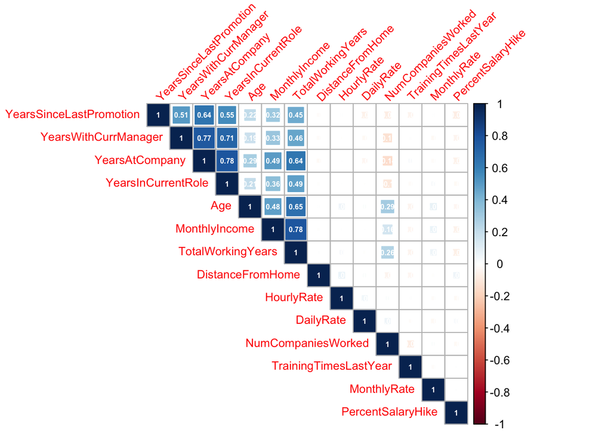

```r
corrFrito <- frito3

corrFritotable <- corrFrito %>% keep(is.numeric) %>% na.omit %>% cor %>% view

corrFrito %>% keep(is.numeric) %>% na.omit %>% cor %>% corrplot("upper", addCoef.col = "white", number.digits = 2, number.cex = 0.5, method="square", order="hclust", tl.srt=45, tl.cex = 0.8)
```

```r
invisible(view(corrFritotable))
```

#### Correlation Review

```r
skim(frito3)
```

```
## Skim summary statistics
##  n obs: 870
##  n variables: 30
##
## ── Variable type:factor ──────────────────────────────────────────────────────────────────────────────────────────────────
##                  variable missing complete   n n_unique
##                 Attrition       0      870 870        2
##            BusinessTravel       0      870 870        3
##                Department       0      870 870        3
##                 Education       0      870 870        5
##            EducationField       0      870 870        6
##   EnvironmentSatisfaction       0      870 870        4
##                    Gender       0      870 870        2
##            JobInvolvement       0      870 870        4
##                  JobLevel       0      870 870        5
##                   JobRole       0      870 870        9
##           JobSatisfaction       0      870 870        4
##             MaritalStatus       0      870 870        3
##                  OverTime       0      870 870        2
##  RelationshipSatisfaction       0      870 870        4
##          StockOptionLevel       0      870 870        4
##           WorkLifeBalance       0      870 870        4
##                             top_counts ordered
##               No: 730, Yes: 140, NA: 0   FALSE
##     Tra: 618, Tra: 158, Non: 94, NA: 0   FALSE
##     Res: 562, Sal: 273, Hum: 35, NA: 0   FALSE
##          3: 324, 4: 240, 2: 182, 1: 98   FALSE
##  Lif: 358, Med: 270, Mar: 100, Tec: 75   FALSE
##         4: 262, 3: 258, 2: 178, 1: 172   FALSE
##              Mal: 516, Fem: 354, NA: 0   FALSE
##           3: 514, 2: 228, 4: 81, 1: 47   FALSE
##          1: 329, 2: 312, 3: 132, 4: 60   FALSE
##  Sal: 200, Res: 172, Lab: 153, Man: 87   FALSE
##         4: 271, 3: 254, 1: 179, 2: 166   FALSE
##    Mar: 410, Sin: 269, Div: 191, NA: 0   FALSE
##               No: 618, Yes: 252, NA: 0   FALSE
##         4: 264, 3: 261, 1: 174, 2: 171   FALSE
##           0: 379, 1: 355, 2: 81, 3: 55   FALSE
##           3: 532, 2: 192, 4: 98, 1: 48   FALSE
##
```

[output cut: 16 more lines]

```
##      p50      p75  p100     hist
##     35      43       60 ▁▃▆▇▅▃▂▂
##    817.5  1165.75  1499 ▆▆▇▇▇▆▇▇
##      7      14       29 ▇▅▃▁▁▁▁▁
##     66      83      100 ▆▇▇▇▆▇▇▇
##   4945.5  8182    19999 ▇▇▃▂▁▁▁▁
##  14074.5 20456.25 26997 ▆▇▇▇▇▆▇▆
##      2       4        9 ▇▂▂▂▁▁▁▁
##     14      18       25 ▇▇▃▃▁▂▂▁
##     10      15       40 ▅▇▂▂▁▁▁▁
##      3       3        6 ▁▁▇▇▁▂▂▁
##      5      10       40 ▇▅▁▁▁▁▁▁
##      3       7       18 ▇▂▁▅▁▁▁▁
##      1       3       15 ▇▂▁▁▁▁▁▁
##      3       7       17 ▇▂▁▃▁▁▁▁
```

```r
frito3 <- select(frito3, -c("YearsAtCompany"))
skim(frito3)
```

```
## Skim summary statistics
##  n obs: 870
##  n variables: 29
##
## ── Variable type:factor ──────────────────────────────────────────────────────────────────────────────────────────────────
##                  variable missing complete   n n_unique
##                 Attrition       0      870 870        2
##            BusinessTravel       0      870 870        3
##                Department       0      870 870        3
##                 Education       0      870 870        5
##            EducationField       0      870 870        6
##   EnvironmentSatisfaction       0      870 870        4
##                    Gender       0      870 870        2
##            JobInvolvement       0      870 870        4
##                  JobLevel       0      870 870        5
##                   JobRole       0      870 870        9
##           JobSatisfaction       0      870 870        4
##             MaritalStatus       0      870 870        3
##                  OverTime       0      870 870        2
##  RelationshipSatisfaction       0      870 870        4
##          StockOptionLevel       0      870 870        4
##           WorkLifeBalance       0      870 870        4
##                             top_counts ordered
##               No: 730, Yes: 140, NA: 0   FALSE
##     Tra: 618, Tra: 158, Non: 94, NA: 0   FALSE
##     Res: 562, Sal: 273, Hum: 35, NA: 0   FALSE
##          3: 324, 4: 240, 2: 182, 1: 98   FALSE
##  Lif: 358, Med: 270, Mar: 100, Tec: 75   FALSE
##         4: 262, 3: 258, 2: 178, 1: 172   FALSE
##              Mal: 516, Fem: 354, NA: 0   FALSE
##           3: 514, 2: 228, 4: 81, 1: 47   FALSE
##          1: 329, 2: 312, 3: 132, 4: 60   FALSE
##  Sal: 200, Res: 172, Lab: 153, Man: 87   FALSE
##         4: 271, 3: 254, 1: 179, 2: 166   FALSE
##    Mar: 410, Sin: 269, Div: 191, NA: 0   FALSE
##               No: 618, Yes: 252, NA: 0   FALSE
##         4: 264, 3: 261, 1: 174, 2: 171   FALSE
##           0: 379, 1: 355, 2: 81, 3: 55   FALSE
##           3: 532, 2: 192, 4: 98, 1: 48   FALSE
##
```

[output cut: 14 more lines]

```
##     YearsWithCurrManager       0      870 870     4.14    3.57    0    2
##      p50      p75  p100     hist
##     35      43       60 ▁▃▆▇▅▃▂▂
##    817.5  1165.75  1499 ▆▆▇▇▇▆▇▇
##      7      14       29 ▇▅▃▁▁▁▁▁
##     66      83      100 ▆▇▇▇▆▇▇▇
##   4945.5  8182    19999 ▇▇▃▂▁▁▁▁
##  14074.5 20456.25 26997 ▆▇▇▇▇▆▇▆
##      2       4        9 ▇▂▂▂▁▁▁▁
##     14      18       25 ▇▇▃▃▁▂▂▁
##     10      15       40 ▅▇▂▂▁▁▁▁
##      3       3        6 ▁▁▇▇▁▂▂▁
##      3       7       18 ▇▂▁▅▁▁▁▁
##      1       3       15 ▇▂▁▁▁▁▁▁
##      3       7       17 ▇▂▁▃▁▁▁▁
```

```r
ncol(frito3)
```

```
## [1] 29
```

### 7. Numeric v Categorical

- X | Y
- Comparison of Attrition (dependent variable of interest) to numerical variables left in model
- Density plot
  - Colored by Attrition
  - If density plot shows peaks in separate areas then important variable
  - If density plot shows peaks in the same spot (clean overlay) then not an important variable

```r
skim(frito3)
```

```
## Skim summary statistics
##  n obs: 870
##  n variables: 29
##
## ── Variable type:factor ──────────────────────────────────────────────────────────────────────────────────────────────────
##                  variable missing complete   n n_unique
##                 Attrition       0      870 870        2
##            BusinessTravel       0      870 870        3
##                Department       0      870 870        3
##                 Education       0      870 870        5
##            EducationField       0      870 870        6
##   EnvironmentSatisfaction       0      870 870        4
##                    Gender       0      870 870        2
##            JobInvolvement       0      870 870        4
##                  JobLevel       0      870 870        5
##                   JobRole       0      870 870        9
##           JobSatisfaction       0      870 870        4
##             MaritalStatus       0      870 870        3
##                  OverTime       0      870 870        2
##  RelationshipSatisfaction       0      870 870        4
##          StockOptionLevel       0      870 870        4
##           WorkLifeBalance       0      870 870        4
##                             top_counts ordered
##               No: 730, Yes: 140, NA: 0   FALSE
##     Tra: 618, Tra: 158, Non: 94, NA: 0   FALSE
##     Res: 562, Sal: 273, Hum: 35, NA: 0   FALSE
##          3: 324, 4: 240, 2: 182, 1: 98   FALSE
##  Lif: 358, Med: 270, Mar: 100, Tec: 75   FALSE
##         4: 262, 3: 258, 2: 178, 1: 172   FALSE
##              Mal: 516, Fem: 354, NA: 0   FALSE
##           3: 514, 2: 228, 4: 81, 1: 47   FALSE
##          1: 329, 2: 312, 3: 132, 4: 60   FALSE
##  Sal: 200, Res: 172, Lab: 153, Man: 87   FALSE
##         4: 271, 3: 254, 1: 179, 2: 166   FALSE
##    Mar: 410, Sin: 269, Div: 191, NA: 0   FALSE
##               No: 618, Yes: 252, NA: 0   FALSE
##         4: 264, 3: 261, 1: 174, 2: 171   FALSE
##           0: 379, 1: 355, 2: 81, 3: 55   FALSE
##           3: 532, 2: 192, 4: 98, 1: 48   FALSE
##
```

[output cut: 14 more lines]

```
##     YearsWithCurrManager       0      870 870     4.14    3.57    0    2
##      p50      p75  p100     hist
##     35      43       60 ▁▃▆▇▅▃▂▂
##    817.5  1165.75  1499 ▆▆▇▇▇▆▇▇
##      7      14       29 ▇▅▃▁▁▁▁▁
##     66      83      100 ▆▇▇▇▆▇▇▇
##   4945.5  8182    19999 ▇▇▃▂▁▁▁▁
##  14074.5 20456.25 26997 ▆▇▇▇▇▆▇▆
##      2       4        9 ▇▂▂▂▁▁▁▁
##     14      18       25 ▇▇▃▃▁▂▂▁
##     10      15       40 ▅▇▂▂▁▁▁▁
##      3       3        6 ▁▁▇▇▁▂▂▁
##      3       7       18 ▇▂▁▅▁▁▁▁
##      1       3       15 ▇▂▁▁▁▁▁▁
##      3       7       17 ▇▂▁▃▁▁▁▁
```

#### Automated EDA: Numeric v Catgorical: all at once

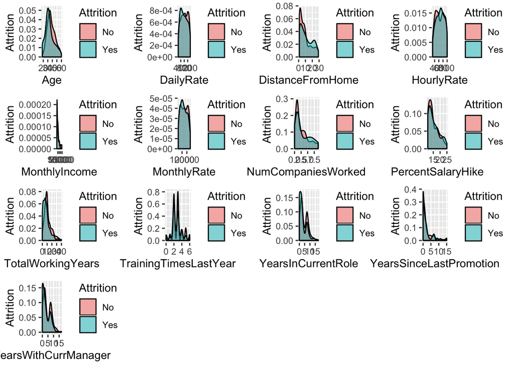

```r
# 1. Name target variable
targetNumCat <- "Attrition"

# 2. Name explanatory variable
numvariables <- frito3 %>% keep(is.numeric) %>% colnames

# 3. Create function
numCatplot <- function(df, explan, resp) {
  ggplot(data = df) + geom_density(aes_string(x = explan, fill = resp), alpha = 0.5) + xlab(explan) + ylab("Attrition")
}

  # Example of working function above
  #numCatplot(frito3, explan =  "TotalWorkingYears", resp = "Attrition")

# 4. Create plot list for plot_grid function to reference
plotlistNumCat <- lapply(numvariables, function(x) numCatplot(frito3, x, targetNumCat))

# 5. Grid of all categorical variables plotted against Attrition
plot_grid(plotlist = plotlistNumCat)
```

#### After Numeric v Categorical Review

- Remove variables that have similar trends
  - Telling the same story
  - e.g. “DailyRate”, “HourlyRate”, “TotalWorkingYears”, “MonthlyRate”, “YearsWithCurrManager”, “YearsAtCompany”, “YearsSinceLastPromotion”
- Remove variables that show the Yes and No of Attrition having the same patterns
  - “TrainingTimesLastYear”, “PercentSalaryHike”, “DistanceFromHome”
- Keep variables that are showing opposite peaks as in the graphs
  - “MonthlyIncome”, “YearsInCurrentRole”, “NumCompaniesWorked”, “Age”

```r
skim(frito3)
```

```
## Skim summary statistics
##  n obs: 870
##  n variables: 29
##
## ── Variable type:factor ──────────────────────────────────────────────────────────────────────────────────────────────────
##                  variable missing complete   n n_unique
##                 Attrition       0      870 870        2
##            BusinessTravel       0      870 870        3
##                Department       0      870 870        3
##                 Education       0      870 870        5
##            EducationField       0      870 870        6
##   EnvironmentSatisfaction       0      870 870        4
##                    Gender       0      870 870        2
##            JobInvolvement       0      870 870        4
##                  JobLevel       0      870 870        5
##                   JobRole       0      870 870        9
##           JobSatisfaction       0      870 870        4
##             MaritalStatus       0      870 870        3
##                  OverTime       0      870 870        2
##  RelationshipSatisfaction       0      870 870        4
##          StockOptionLevel       0      870 870        4
##           WorkLifeBalance       0      870 870        4
##                             top_counts ordered
##               No: 730, Yes: 140, NA: 0   FALSE
##     Tra: 618, Tra: 158, Non: 94, NA: 0   FALSE
##     Res: 562, Sal: 273, Hum: 35, NA: 0   FALSE
##          3: 324, 4: 240, 2: 182, 1: 98   FALSE
##  Lif: 358, Med: 270, Mar: 100, Tec: 75   FALSE
##         4: 262, 3: 258, 2: 178, 1: 172   FALSE
##              Mal: 516, Fem: 354, NA: 0   FALSE
##           3: 514, 2: 228, 4: 81, 1: 47   FALSE
##          1: 329, 2: 312, 3: 132, 4: 60   FALSE
##  Sal: 200, Res: 172, Lab: 153, Man: 87   FALSE
##         4: 271, 3: 254, 1: 179, 2: 166   FALSE
##    Mar: 410, Sin: 269, Div: 191, NA: 0   FALSE
##               No: 618, Yes: 252, NA: 0   FALSE
##         4: 264, 3: 261, 1: 174, 2: 171   FALSE
##           0: 379, 1: 355, 2: 81, 3: 55   FALSE
##           3: 532, 2: 192, 4: 98, 1: 48   FALSE
##
```

[output cut: 14 more lines]

```
##     YearsWithCurrManager       0      870 870     4.14    3.57    0    2
##      p50      p75  p100     hist
##     35      43       60 ▁▃▆▇▅▃▂▂
##    817.5  1165.75  1499 ▆▆▇▇▇▆▇▇
##      7      14       29 ▇▅▃▁▁▁▁▁
##     66      83      100 ▆▇▇▇▆▇▇▇
##   4945.5  8182    19999 ▇▇▃▂▁▁▁▁
##  14074.5 20456.25 26997 ▆▇▇▇▇▆▇▆
##      2       4        9 ▇▂▂▂▁▁▁▁
##     14      18       25 ▇▇▃▃▁▂▂▁
##     10      15       40 ▅▇▂▂▁▁▁▁
##      3       3        6 ▁▁▇▇▁▂▂▁
##      3       7       18 ▇▂▁▅▁▁▁▁
##      1       3       15 ▇▂▁▁▁▁▁▁
##      3       7       17 ▇▂▁▃▁▁▁▁
```

```r
frito4 <- select(frito3, -c("TrainingTimesLastYear", "PercentSalaryHike", "DistanceFromHome", "DailyRate", "HourlyRate", "TotalWorkingYears", "MonthlyRate", "YearsWithCurrManager", "YearsSinceLastPromotion"))
skim(frito4)
```

```
## Skim summary statistics
##  n obs: 870
##  n variables: 20
##
## ── Variable type:factor ──────────────────────────────────────────────────────────────────────────────────────────────────
##                  variable missing complete   n n_unique
##                 Attrition       0      870 870        2
##            BusinessTravel       0      870 870        3
##                Department       0      870 870        3
##                 Education       0      870 870        5
##            EducationField       0      870 870        6
##   EnvironmentSatisfaction       0      870 870        4
##                    Gender       0      870 870        2
##            JobInvolvement       0      870 870        4
##                  JobLevel       0      870 870        5
##                   JobRole       0      870 870        9
##           JobSatisfaction       0      870 870        4
##             MaritalStatus       0      870 870        3
##                  OverTime       0      870 870        2
##  RelationshipSatisfaction       0      870 870        4
##          StockOptionLevel       0      870 870        4
##           WorkLifeBalance       0      870 870        4
##                             top_counts ordered
##               No: 730, Yes: 140, NA: 0   FALSE
##     Tra: 618, Tra: 158, Non: 94, NA: 0   FALSE
##     Res: 562, Sal: 273, Hum: 35, NA: 0   FALSE
##          3: 324, 4: 240, 2: 182, 1: 98   FALSE
##  Lif: 358, Med: 270, Mar: 100, Tec: 75   FALSE
##         4: 262, 3: 258, 2: 178, 1: 172   FALSE
##              Mal: 516, Fem: 354, NA: 0   FALSE
##           3: 514, 2: 228, 4: 81, 1: 47   FALSE
##          1: 329, 2: 312, 3: 132, 4: 60   FALSE
##  Sal: 200, Res: 172, Lab: 153, Man: 87   FALSE
##         4: 271, 3: 254, 1: 179, 2: 166   FALSE
##    Mar: 410, Sin: 269, Div: 191, NA: 0   FALSE
##               No: 618, Yes: 252, NA: 0   FALSE
##         4: 264, 3: 261, 1: 174, 2: 171   FALSE
##           0: 379, 1: 355, 2: 81, 3: 55   FALSE
##           3: 532, 2: 192, 4: 98, 1: 48   FALSE
##
## ── Variable type:integer ─────────────────────────────────────────────────────────────────────────────────────────────────
##            variable missing complete   n    mean      sd   p0    p25
##                 Age       0      870 870   36.83    8.93   18   30
##       MonthlyIncome       0      870 870 6390.26 4597.7  1081 2839.5
##  NumCompaniesWorked       0      870 870    2.73    2.52    0    1
##  YearsInCurrentRole       0      870 870    4.2     3.64    0    2
##     p50  p75  p100     hist
##    35     43    60 ▁▃▆▇▅▃▂▂
##  4945.5 8182 19999 ▇▇▃▂▁▁▁▁
##     2      4     9 ▇▂▂▂▁▁▁▁
##     3      7    18 ▇▂▁▅▁▁▁▁
```

```r
ncol(frito4)
```

```
## [1] 20
```

#### Completed Comparison Analysis

#### Attrition v Age

```r
invisible(frito3 %>% ggplot() + geom_density(aes(x = Age, fill = Attrition, alpha = .1)) +
  theme_excel_new() + ggtitle("Attrition v Age") + ylab("Attrition") + xlab("Age"))
```

#### Attrition v Daily Rate

```r
invisible(frito3 %>% ggplot() + geom_density(aes(x = DailyRate, fill = Attrition, alpha = 0.1)) +
  theme_excel_new() + ggtitle("Attrition v Daily Rate") + ylab("Attrition") + xlab("Daily Rate"))
```

#### Attrition v Distance From Home

```r
invisible(frito3 %>% ggplot() + geom_density(aes(x = DistanceFromHome, fill = Attrition, alpha = 0.1)) +
  theme_excel_new() + ggtitle("Attrition v Distance From Home") + ylab("Attrition") + xlab("Distance From Home"))
```

#### Attrition v Hourly Rate

```r
invisible(frito3 %>% ggplot() + geom_density(aes(x = HourlyRate, fill = Attrition, alpha = 0.1)) +
  theme_excel_new() + ggtitle("Attrition v Hourly Rate") + ylab("Attrition") + xlab("Hourly Rate"))
```

#### Attrition v Monthly Income

```r
invisible(frito3 %>% ggplot() + geom_density(aes(x = MonthlyIncome, fill = Attrition, alpha = 0.1)) +
  theme_excel_new() + ggtitle("Attrition v Monthly Income") + ylab("Attrition") + xlab("Monthly Income"))
```

#### Attrition v Number of Companies Worked

```r
invisible(frito3 %>% ggplot() + geom_density(aes(x = NumCompaniesWorked, fill = Attrition, alpha = 0.1)) +
  theme_excel_new() + ggtitle("Attrition v Number of Companies Worked") + ylab("Attrition") + xlab("Number of Companies Worked"))
```

#### Attrition v Percent Salary Hike

```r
invisible(frito3 %>% ggplot() + geom_density(aes(x = PercentSalaryHike, fill = Attrition, alpha = 0.1)) +
  theme_excel_new() + ggtitle("Attrition v Percent Salary Hike") + ylab("Attrition") + xlab("Percent Salary Hike"))
```

#### Attrition v Years with Current Manager

```r
invisible(frito3 %>% ggplot() + geom_density(aes(x = YearsWithCurrManager, fill = Attrition, alpha = 0.1)) +
  theme_excel_new() + ggtitle("Attrition v Years with Current Manager") + ylab("Attrition") + xlab("Years with Current Manager"))
```

#### Attrition v Training Times Last Year

```r
invisible(frito3 %>% ggplot() + geom_density(aes(x = TrainingTimesLastYear, fill = Attrition, alpha = 0.1)) +
  theme_excel_new() + ggtitle("Attrition v Training Times Last Year") + ylab("Attrition") + xlab("Training Times Last Year"))
```

#### Attrition v Years in Current Role

```r
invisible(frito3 %>% ggplot() + geom_density(aes(x = YearsInCurrentRole, fill = Attrition, alpha = 0.1)) +
  theme_excel_new() + ggtitle("Attrition v Years in Current Role") + ylab("Attrition") + xlab("Years in Current Role"))
```

#### Attrition v Years Since Last Promotion

```r
invisible(frito3 %>% ggplot() + geom_density(aes(x = YearsSinceLastPromotion, fill = Attrition, alpha = 0.1)) +
  theme_excel_new() + ggtitle("Attrition v Years Since Last Promotion") + ylab("Attrition") + xlab("Years Since Last Promotion"))
```

#### Attrition v Total Working Years

```r
invisible(frito3 %>% ggplot() + geom_density(aes(x = TotalWorkingYears, fill = Attrition, alpha = 0.1)) +
  theme_excel_new() + ggtitle("Attrition v Total Working Years") + ylab("Attrition") + xlab("Years Since Last Promotion"))
```

### 8. Categorical v Categorical (Attrition)

- Y | Fill
- Comparison of Attrition (dependent variable of interest) to categorical variables in model
- Bar chart with percentages instead of totals
  - Colored by Attrition
  - If bar chart shows a large difference within the levels/categories of the y variable then it is identified as an important variable to include in the model
  - If bar chart shows a small or zero difference within the levels/categories of the y variable then it is not an important variable to include in the model

```r
str(frito4)
```

```
## 'data.frame':    870 obs. of  20 variables:
##  $ Age                     : int  32 40 35 32 24 27 41 37 34 34 ...
##  $ Attrition               : Factor w/ 2 levels "No","Yes": 1 1 1 1 1 1 1 1 1 1 ...
##  $ BusinessTravel          : Factor w/ 3 levels "Non-Travel","Travel_Frequently",..: 3 3 2 3 2 2 3 3 3 2 ...
##  $ Department              : Factor w/ 3 levels "Human Resources",..: 3 2 2 3 2 2 2 3 3 2 ...
##  $ Education               : Factor w/ 5 levels "1","2","3","4",..: 4 3 2 4 1 2 5 4 4 4 ...
##  $ EducationField          : Factor w/ 6 levels "Human Resources",..: 2 4 2 3 6 2 4 2 2 6 ...
##  $ EnvironmentSatisfaction : Factor w/ 4 levels "1","2","3","4": 2 3 3 3 1 4 2 4 3 4 ...
##  $ Gender                  : Factor w/ 2 levels "Female","Male": 2 2 2 1 1 2 2 1 1 2 ...
##  $ JobInvolvement          : Factor w/ 4 levels "1","2","3","4": 3 2 3 3 3 3 4 2 3 2 ...
##  $ JobLevel                : Factor w/ 5 levels "1","2","3","4",..: 2 5 3 3 1 3 1 2 1 2 ...
##  $ JobRole                 : Factor w/ 9 levels "Healthcare Representative",..: 8 6 5 8 7 5 7 8 9 1 ...
##  $ JobSatisfaction         : Factor w/ 4 levels "1","2","3","4": 4 3 4 4 4 1 3 4 3 3 ...
##  $ MaritalStatus           : Factor w/ 3 levels "Divorced","Married",..: 1 3 3 2 3 1 2 1 2 2 ...
##  $ MonthlyIncome           : int  4403 19626 9362 10422 3760 8793 2127 6694 2220 5063 ...
##  $ NumCompaniesWorked      : int  2 1 2 1 1 1 2 2 1 1 ...
##  $ OverTime                : Factor w/ 2 levels "No","Yes": 1 1 1 1 2 1 2 2 2 1 ...
##  $ RelationshipSatisfaction: Factor w/ 4 levels "1","2","3","4": 3 1 3 3 3 3 1 3 4 2 ...
##  $ StockOptionLevel        : Factor w/ 4 levels "0","1","2","3": 2 1 1 3 1 3 1 4 2 2 ...
##  $ WorkLifeBalance         : Factor w/ 4 levels "1","2","3","4": 2 4 3 3 3 2 2 3 3 2 ...
##  $ YearsInCurrentRole      : int  2 7 2 10 3 7 2 0 1 2 ...
```

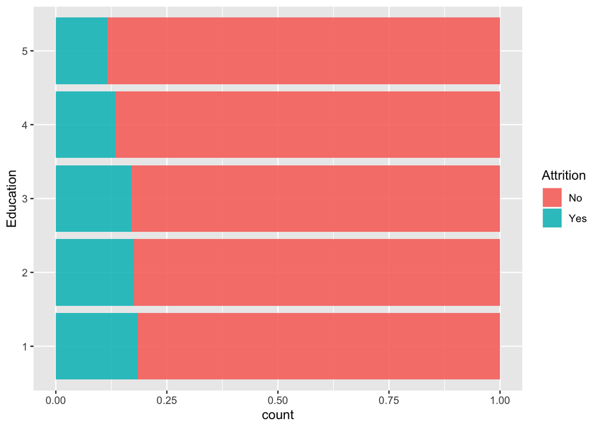

```r
frito4 %>% ggplot() + geom_bar(aes(x = Education, fill = Attrition), position = "fill", alpha = 0.9) + coord_flip()
```

#### Automated EDA: Categorical v Categorical (Attrition) all at once

[figure not shown]

```r
# 1. Name target variable
targetCatCat <- "Attrition"

# 2. Name explanatory variable
explanatory <- frito4 %>% keep(is.factor) %>% colnames

# 3. Create function
numCatCat <- function(df, explanatory, response) {
  ggplot(data = df) +geom_bar(aes_string(x = explanatory, fill = response), position = "fill", alpha = 0.9) + coord_flip() + xlab(explanatory)
}

  # Example of working function above
  #numCatCat(frito4, explanatory = "Education", response = "Attrition")


# 4. Create plot list for plot_grid function to reference
plotlistCatCat <- lapply(explanatory, function(x) numCatCat(frito3, x, targetCatCat))

# 5. Grid of all categorical variables plotted against Attrition
plot_grid(plotlist = plotlistCatCat)
```

#### After Categorical v Categorical Review

- Remove variables that show a small | zero difference within the levels/categories of the y variable
  - “BusinessTravel”, “Department”, “Education”, “EducationField”, “EnvironmentSatisfaction”, “Gender”, “JobRole”, “JobSatisfaction”, “MartialStatus”, “RelationshipSatisfaction”, “JobLevel”
- Keep variables that show a large difference within the levels/categories of the y variable
  - “JobInvolvement”, “WorkLifeBalance”, “Overtime”, “StockOptionLevel”

```r
#skim(frito4)

frito5 <- select(frito4, -c("BusinessTravel", "Department", "Education", "EducationField", "EnvironmentSatisfaction", "Gender", "JobRole", "JobSatisfaction", "MaritalStatus", "RelationshipSatisfaction", "JobLevel"))
#skim(frito5)
ncol(frito5)
```

```
## [1] 9
```

```r
#view(frito5)
#str(frito5)
frito6 <- frito5 %>%
  mutate(OverTime = ifelse(OverTime == "No", 0, 1))
frito6 <- frito5 %>%
  mutate(Attrition = ifelse(Attrition ==  "No", 0, 1))
#view(frito6)
```

### Review of multiple models

```r
set.seed(8)
splitPerc = .8
trnIndFrito = sample(1:dim(frito6)[1], round(splitPerc * dim(frito6)[1]))

trainFrito = frito6[trnIndFrito,]

testFrito = frito6[-trnIndFrito,]
```

```r
#invisible(knn(trainFrito[,c(1,3,4)], testFrito[,c(1,3,4)], trainFrito$Attrition, prob = TRUE, k=19))
#classificationFrito = knn(trainFrito[,c(1,3,4)], testFrito[,c(1,3,4)], trainFrito$Attrition, prob = TRUE, k=19)
#CMFrito1.1 = confusionMatrix(table(testFrito$Attrition, classificationFrito))
#CMFrito1.1
```

#### 2. Job Involvement, Monthly Income, Number Companies Worked

```r
#invisible(knn(trainFrito[,c(3,4,5)], testFrito[,c(3,4,5)], trainFrito$Attrition, prob = TRUE, k=19))
#classificationFrito = knn(trainFrito[,c(3,4,5)], testFrito[,c(3,4,5)], trainFrito$Attrition, prob = TRUE, k=19)
#CMFrito2 = confusionMatrix(table(testFrito$Attrition, classificationFrito))
#CMFrito2
```

#### 3. Monthly Income, Number of Companies Worked, Over Time

```r
#invisible(knn(trainFrito[,c(4,5,6)], testFrito[,c(4,5,6)], trainFrito$Attrition, prob = TRUE, k=7))
#classificationFrito = knn(trainFrito[,c(4,5,6)], testFrito[,c(4,5,6)], trainFrito$Attrition, prob = TRUE, k=7)
#CMFrito3 = confusionMatrix(table(testFrito$Attrition, classificationFrito))
#CMFrito3
```

#### 4. Number of Companies Worked, Over Time, Stock Option Level

```r
#invisible(knn(trainFrito[,c(5,6,7)], testFrito[,c(5,6,7)], trainFrito$Attrition, prob = TRUE, k=7))
#classificationFrito = knn(trainFrito[,c(5,6,7)], testFrito[,c(5,6,7)], trainFrito$Attrition, prob = TRUE, k=7)
#CMFrito5 = confusionMatrix(table(testFrito$Attrition, classificationFrito))
#CMFrito5
```

```r
#invisible(knn(trainFrito[,c(6,7,8)], testFrito[,c(6,7,8)], trainFrito$Attrition, prob = TRUE, k=7))
#classificationFrito = knn(trainFrito[,c(6,7,8)], testFrito[,c(6,7,8)], trainFrito$Attrition, prob = TRUE, k=7)
#CMFrito6 = confusionMatrix(table(testFrito$Attrition, classificationFrito))
#CMFrito6
```

#### 6. Stock Option Level, Work Life Balance, Age

```r
#invisible(knn(trainFrito[,c(7,8,1)], testFrito[,c(7,8,1)], trainFrito$Attrition, prob = TRUE, k=7))
#classificationFrito = knn(trainFrito[,c(7,8,1)], testFrito[,c(7,8,1)], trainFrito$Attrition, prob = TRUE, k=7)
#CMFrito7 = confusionMatrix(table(testFrito$Attrition, classificationFrito))
#CMFrito7
```

```r
#invisible(knn(trainFrito[,c(8,1,3)], testFrito[,c(8,1,3)], trainFrito$Attrition, prob = TRUE, k= 19))
#classificationFrito = knn(trainFrito[,c(8,1,3)], testFrito[,c(8,1,3)], trainFrito$Attrition, prob = TRUE, k= 19)
#CMFrito8 = confusionMatrix(table(testFrito$Attrition, classificationFrito))
#CMFrito8
```

#### 8. Montly Income (4) Over Time(6) Stock Option Level (7)

```r
#invisible(knn(trainFrito[,c(4,6,7)], testFrito[,c(4,6,7)], trainFrito$Attrition, prob = TRUE, k=19))
#classificationFrito = knn(trainFrito[,c(4,6,7)], testFrito[,c(4,6,7)], trainFrito$Attrition, prob = TRUE, k=19)
#CMFrito8 = confusionMatrix(table(testFrito$Attrition, classificationFrito))
#CMFrito8
```

#### Find best k for Model 7

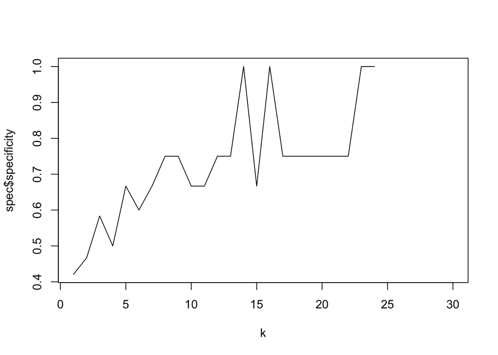

```r
set.seed(8)
splitPerc = .8
trnIndFrito = sample(1:dim(frito6)[1], round(splitPerc * dim(frito6)[1]))

trainFrito = frito6[trnIndFrito,]

testFrito = frito6[-trnIndFrito,]

spec = data.frame(specificity = numeric(30), k = numeric(30))
for (i in 1:30)
  {
  classificationFrito = knn(trainFrito[,c(8,1,3)], testFrito[,c(8,1,3)], trainFrito$Attrition, prob = TRUE, k=i)
  table(testFrito$Attrition, classificationFrito)
  CMFrito8 = confusionMatrix(table(testFrito$Attrition, classificationFrito))
  spec$specificity[i] = CMFrito8$byClass[2]
  spec$k[i] = i
}
plot(spec$k, spec$specificity, type = "l", xlab = "k")
```

```r
#k <- which.max(spec$specificity)
```

#### Final Model (7)

```r
invisible(knn(trainFrito[,c(8,1,3)], testFrito[,c(8,1,3)], trainFrito$Attrition, prob = TRUE, k= 19))
classificationFrito = knn(trainFrito[,c(8,1,3)], testFrito[,c(8,1,3)], trainFrito$Attrition, prob = TRUE, k= 19)
CMFrito8 = confusionMatrix(table(testFrito$Attrition, classificationFrito))
CMFrito8
```

```
## Confusion Matrix and Statistics
##
##    classificationFrito
##       0   1
##   0 144   1
##   1  26   3
##
##                Accuracy : 0.8448
##                  95% CI : (0.7823, 0.8952)
##     No Information Rate : 0.977
##     P-Value [Acc > NIR] : 1
##
##                   Kappa : 0.1474
##
##  Mcnemar's Test P-Value : 3.86e-06
##
##             Sensitivity : 0.8471
##             Specificity : 0.7500
##          Pos Pred Value : 0.9931
##          Neg Pred Value : 0.1034
##              Prevalence : 0.9770
##          Detection Rate : 0.8276
##    Detection Prevalence : 0.8333
##       Balanced Accuracy : 0.7985
##
##        'Positive' Class : 0
##
```

## Competition Set Analysis

```r
competition <- read.csv("https://raw.githubusercontent.com/JaclynCoate/MDS-6306-Doing-Data-Science-Fall-2019/Master/Unit%2014%20and%2015%20Case%20Study%202/CaseStudy2CompSet%20No%20Attrition.csv", header = TRUE, strip.white=TRUE)
invisible(competition)
```

## KNN Model Used to Predict Attrition

```r
#Work Life Balance, Years in Current Role, Age
competition <- select(competition, c("ID", "WorkLifeBalance", "YearsInCurrentRole", "Age"))

estimates <- data.frame(knn(trainFrito[,c(8,1,3)], competition[,c(2,3,4)], trainFrito$Attrition, prob = TRUE, k = 19))
compFinal <- cbind(competition, estimates)
colnames(compFinal)[5] <- "Attrition"

compFinal <- compFinal %>%
  mutate(Attrition = ifelse(Attrition == 0, "No", "Yes"))
invisible(compFinal)
```

### Checking model results aginst graphical analysis

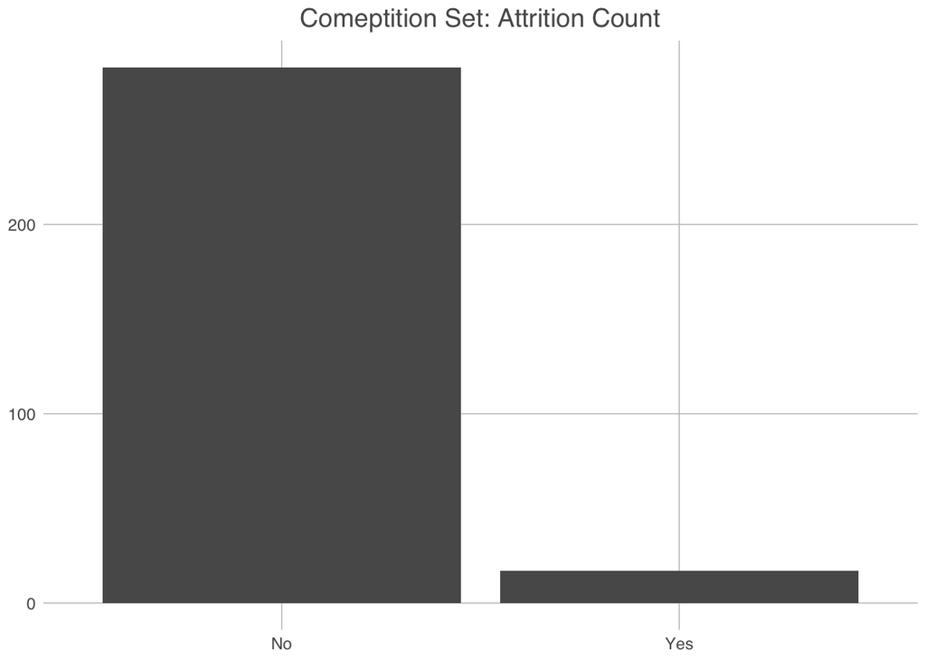

```r
compFinal %>% ggplot(mapping = aes(x = Attrition)) + geom_bar() + ggtitle("Comeptition Set: Attrition Count") + theme_excel_new()
```

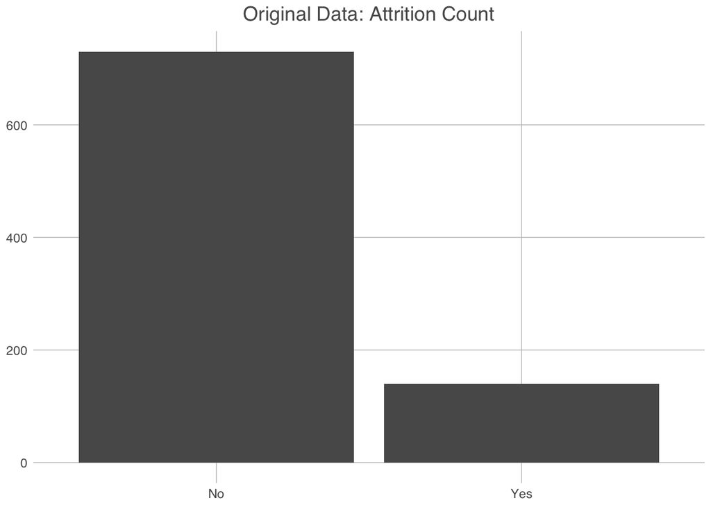

```r
frito %>% ggplot(mapping = aes(x = Attrition)) + geom_bar() + ggtitle("Original Data: Attrition Count") + theme_excel_new()
```

### Checking model results aginst graphical analysis

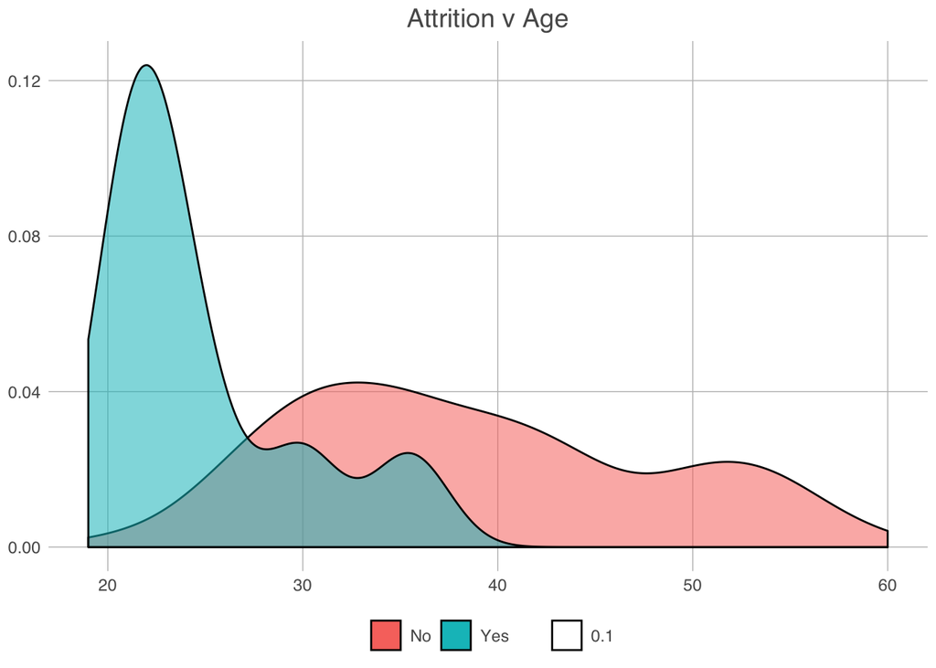

```r
compFinal %>% ggplot() + geom_density(aes(x = Age, fill = Attrition, alpha = .1)) +
  theme_excel_new() + ggtitle("Attrition v Age") + ylab("Attrition") + xlab("Age")
```

### Checking model against graphical analysis

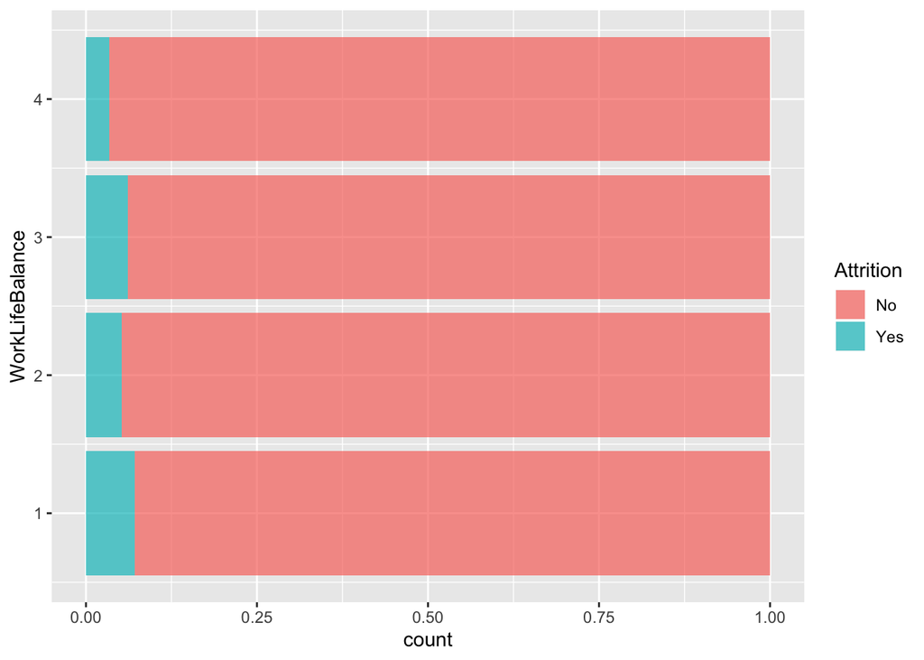

```r
compFinal %>% ggplot() + geom_bar(aes(x = WorkLifeBalance, fill = Attrition), position = "fill", alpha = .7) + coord_flip()
```

### Write to CSV for github

```r
#write_csv(compFinal, "/Users/Jaco/Desktop/SMU/Fall2019/DS_6306_Doing_Data_Science/Unit_14CaseStudy2\\CompetitionSet.csv")
```

# Things I had to walk away from

#### Trying to mean of all three variables

```r
#iterations = 100
#numks = 100
#masterAcc = matrix(nrow = iterations, ncol = numks)
#for(j in 1:iterations) {
#  accs = data.frame(accuracy = numeric(numks), k = numeric(numks))
#  trnIndFrito = sample(1:dim(frito6)[1], round(splitPerc * dim(frito6)[1]))
#  trainFrito = frito6[trnIndFrito,]
#  testFrito = frito6[-trnIndFrito,]
#  for(i in 1:numks) {
#    classificationFrito = knn(trainFrito[,c(8,1,3)], testFrito[,c(8,1,3)], trainFrito$Attrition, prob = TRUE, k=i)
#    table(testFrito$Attrition, classificationFrito)
#    CMFrito8 = confusionMatrix(table(testFrito$Attrition, classificationFrito))
#    masterAcc[j,i] = CMFrito8$overall[1]
#  }
#}

#MeanAcc = colMeans(masterAcc)
#plot(seq(1,numks,1),MeanAcc, type = "l")
#k <- which.max(MeanAcc)

#@@@@@@@@@@@@@@@@@@

#iterations = 500
#masterAcc = matrix(nrow = iterations)
#masterSen = matrix(nrow = iterations)
#masterSpec = matrix(nrow = iterations)
#splitPer = .7
#for (j in 1:iterations)
#  {
#  trnIndFrito = sample(1:dim(frito6)[1],round(splitPerc * dim(frito6)[1]))
#  trainFrito = frito6[trnIndFrito,]
#  testFrito = frito6[-trnIndFrito,]
#
#  classificationFrito = knn(trainFrito[,c(8,1,3)], testFrito[,c(8,1,3)], trainFrito$Attrition, prob = TRUE, k=i)
#  table(testFrito$Attrition, classificationFrito)
#
#  CMFritoInt = confusionMatrix(table(testFrito$Attrition, classificationFrito))
#  masterAcc[j] = CMFritoInt$overall[1]
#  masterSen[j] = CMFritoInt$byClass[1]
#  masterSpec[j] = CMFritoInt$byClass[2]
#}

#MeanAccUFrit = colMeans(masterAcc)
#MeanAccUFrit
#MeanSenFrit = colMeans(masterSen)
#MeanSenFrit
#MeanSpecFrit = colMeans(masterSpec)
#MeanSpecFrit
```

### 10. NaiveBates Model to Reduce Variables

#### 1. All Variable

```r
#set.seed(4)
#splitPerc = .7
#trnIndFrito = sample(1:dim(frito5)[1], round(splitPerc * dim(frito5)[1]))
#trnIndFrito

#trainFrito = frito6[trnIndFrito,]
#trainFrito

#testFrito = frito6[-trnIndFrito,]
#testFrito

#nBfrito1 <- naiveBayes(Attrition ~ . , data = trainFrito)

#predict(nBfrito1, testFrito[,c(1,3,4)], type = "raw")

#table(predict(nBfrito1, testFrito[,c(1,3,4)], type = "raw"), testFrito$Attrition)






#modelU7.s4 <- naiveBayes(Survived ~ . , data =  trainTitanicU7.s4)

#predict(modelU7.s4, testTitanicU7.s4[,c(2,4)], type = "raw")

#table(predict(modelU7.s4, testTitanicU7.s4[,c(2,4)]), testTitanicU7.s4$Survived)

#CMU7.s4 = confusionMatrix(table(predict(modelU7.s4, testTitanicU7.s4[,c(2,4)]), testTitanicU7.s4$Survived))
#CMU7.s4

#knn(trainTitanicU7.s4[,c(2,4)], testTitanicU7.s4[,c(2,4)],trainTitanicU7.s4$Survived, prob = TRUE, k = 11)
#classKNN.s4 = knn(trainTitanicU7.s4[,c(2,4)], testTitanicU7.s4[,c(2,4)],trainTitanicU7.s4$Survived, prob = TRUE, k = 11)
#CMknnU7.s4 = confusionMatrix(table(testTitanicU7.s4$Survived, classKNN.s4))
#CMknnU7.s4
```